```python
import numpy as np
import matplotlib
import matplotlib.pyplot as plt
import os
import pandas as pd
import scipy.stats

#the datasets
%pip install -q scikit-learn seaborn matplotlib pandas scipy
import sklearn.datasets
import sklearn.cluster
from sklearn.preprocessing import StandardScaler

#For better statistical plotting
import seaborn as sns

%matplotlib inline
```

```python
import sys
print("Python used by this notebook:", sys.executable)

try:
    import sklearn
    print("scikit-learn version:", sklearn.__version__)
    ok = True
except Exception as e:
    print("Import error:", e)
    ok = False
```

```
Python used by this notebook: /opt/miniconda3/envs/bern02/bin/python
scikit-learn version: 1.7.2
```

# Using SVD and PCA to reduce dimensions

We will use the iris dataset that is included in the sklearn package and convert the basic data in it to a dataframe

```python
iris = sklearn.datasets.load_iris()
df_iris = pd.DataFrame(iris.data, columns=iris.feature_names)
```

## Task

- investigate what iris contains by reading print(iris['DESCR'])
- and investigate the structure of the data in the dataframe with describe() and by looking at the head of the DataFrame
- Use the "pairplot" from seaborn to investigate the relation between the data, can you by eye discover correlation between the different type of data?

```python
print(iris['DESCR'])

# first few rows
print("\nHead of DataFrame:")
print(df_iris.head())

# Summary statistics
print("\nDescription of DataFrame:")
print(df_iris.describe())
```

```
.. _iris_dataset:

Iris plants dataset
--------------------

**Data Set Characteristics:**

:Number of Instances: 150 (50 in each of three classes)
:Number of Attributes: 4 numeric, predictive attributes and the class
:Attribute Information:
    - sepal length in cm
    - sepal width in cm
    - petal length in cm
    - petal width in cm
    - class:
            - Iris-Setosa
            - Iris-Versicolour
            - Iris-Virginica

:Summary Statistics:

============== ==== ==== ======= ===== ====================
                Min  Max   Mean    SD   Class Correlation
============== ==== ==== ======= ===== ====================
sepal length:   4.3  7.9   5.84   0.83    0.7826
sepal width:    2.0  4.4   3.05   0.43   -0.4194
petal length:   1.0  6.9   3.76   1.76    0.9490  (high!)
petal width:    0.1  2.5   1.20   0.76    0.9565  (high!)
============== ==== ==== ======= ===== ====================

:Missing Attribute Values: None
:Class Distribution: 33.3% for each of 3 classes.
:Creator: R.A. Fisher
:Donor: Michael Marshall (MARSHALL%PLU@io.arc.nasa.gov)
:Date: July, 1988

The famous Iris database, first used by Sir R.A. Fisher. The dataset is taken
from Fisher's paper. Note that it's the same as in R, but not as in the UCI
Machine Learning Repository, which has two wrong data points.

```

[output cut: 45 more lines]

[output not shown]

[figure not shown]

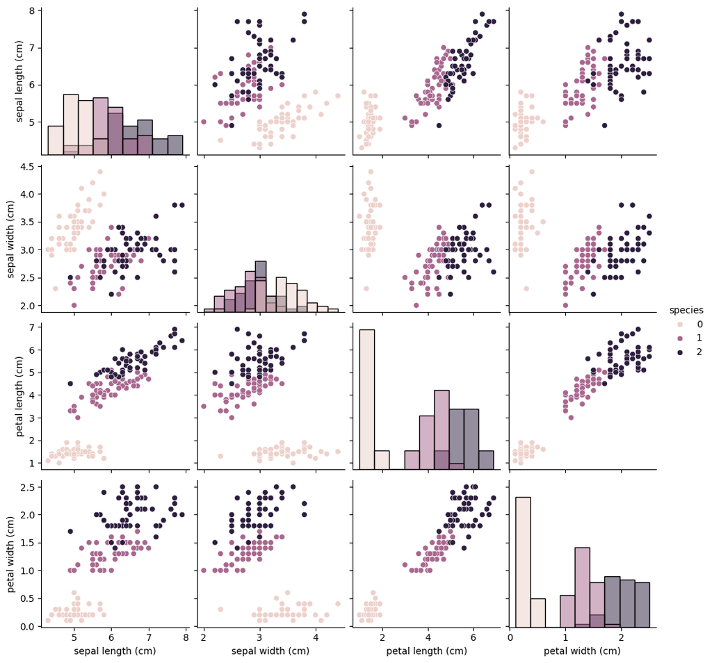

```python
df_iris['species'] = iris.target

# Pairplot with hue = species
sns.pairplot(df_iris, hue="species", diag_kind="hist")
plt.show()
```

#### Answer

The pairplot shows that Iris Setosa (0) is completely separated from the other species using petal length and width. Iris Versicolor (1) and Virginica (2) overlap more, especially when looking only at sepal measurements. The best separation is seen in petal length vs petal width, where Virginica has the largest values, Versicolor is in the middle, and Setosa has the smallest. This means that petal measurements are the most informative features for distinguishing species.

Singular value decomposition factorizes matrix  
$X \in mxn$  
into  
$X = U \, * \, \sum \, * \, V^T$  
Where:

- $U \in m×m$ that is called the left singular vectors where each columns is a orthonormal eigenvectors of $XX^T$
- the diagonal matrix Σ with entries single entries $\in \mathbb{R}$ that are the non-negative singular values of X
- and the right singular vectors in Matrix $V \in n×n$ where the columns are the set of orthonormal eigenvectors of $X^TX$

The SVD algorithm from the numpy package can calculate this quite efficiently

```python
U_iris, S_iris, Vt_iris = np.linalg.svd(df_iris, full_matrices=False)
```

## Task

Plot the cummulative sum of the entries in $S_{iris}^2$ divided by the sum of $S_{iris}^2$ and use the equations 12.8 and 12.9 in the book to label the axis. what is the sum of $S_{iris}^2$? use the answer to label the points in legend of this plot.

```
Explained variance ratio (4 comps): [0.72962445 0.22850762 0.03668922 0.00517871]
Sum of S^2: 600.0000000000001
Two PCs total: 95.81%
```

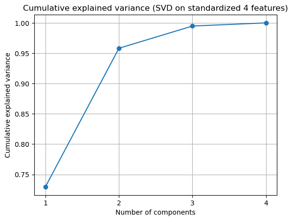

```python
# Using 4 numeric feature columns
feature_cols = iris.feature_names

# Standardize (zero mean, unit variance) for SVD/PCA
X_std = StandardScaler().fit_transform(X4)

# SVD on standardized 4-feature matrix
U, S, VT = np.linalg.svd(X_std, full_matrices=False)
S2 = S**2
total = S2.sum()
ratio = S2 / total
cum = np.cumsum(ratio)

print("Explained variance ratio (4 comps):", ratio)
print("Sum of S^2:", total)
print(f"Two PCs total: {cum[1]*100:.2f}%")

plt.figure()
plt.plot(range(1, len(cum)+1), cum, marker='o')
plt.xticks(range(1, len(cum)+1))
plt.xlabel("Number of components")
plt.ylabel("Cumulative explained variance")
plt.title("Cumulative explained variance (SVD on standardized 4 features)")
plt.grid(True)
plt.show()
```

### Answer

The Iris dataset is highly compressible: The SVD results show that the sum of squared singular values is 600, representing the total variance. The first principal component PC1 explains ~73% of the variance, and the second PC2 ~23%. Together, the first two components capture ~95.8% of the dataset’s variance.

Instead of 4 features, we can use just 2 principal components and still keep ~96% of the information.

- This is why PCA/SVD are useful: we can simplify the data without losing much structure.
- The last two components (PC3, PC4) don’t matter much; they carry very little variance.

This means we can reduce the data from 4D to 2D with very little loss of information. Components 3 and 4 add almost nothing, which confirms that 2D is enough for analysis and visualization.

## Task - visualize the Iris dataset in the new SVD/PCA space

Label the axis in the following plot. It seems as the SVD has selected a vector in which the data is well separated. Try the other vectors and see if you can find other vectors that separate the different flowers.

[figure not shown]

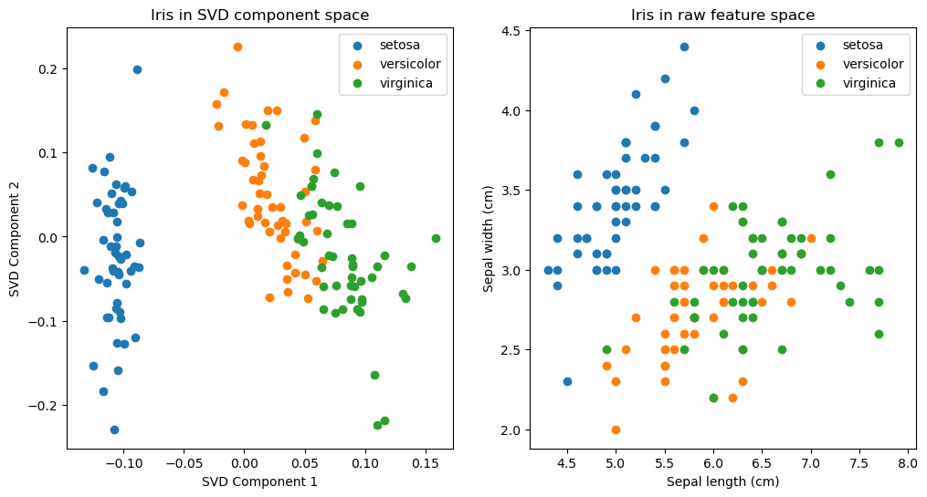

```python
selector = iris['target']   # species labels (0,1,2)
target_names = iris['target_names']

fig, ax = plt.subplots(1, 2, figsize=(12, 6))

# Plot in SVD component space (U[:,0] vs U[:,1])
for i in np.unique(selector):
    ax[0].scatter(U[selector==i, 0], U[selector==i, 1], label=target_names[i])
ax[0].set_xlabel("SVD Component 1")
ax[0].set_ylabel("SVD Component 2")
ax[0].set_title("Iris in SVD component space")
ax[0].legend()

# Plot in original feature space
for i in np.unique(selector):
    ax[1].scatter(df_iris.iloc[selector==i, 0], df_iris.iloc[selector==i, 1], label=target_names[i])
ax[1].set_xlabel("Sepal length (cm)")
ax[1].set_ylabel("Sepal width (cm)")
ax[1].set_title("Iris in raw feature space")
ax[1].legend()

plt.show()
```

### Answer

In the raw feature space (sepal length vs sepal width), the species overlap heavily, and it is difficult to distinguish Versicolor from Virginica.

In the SVD space (first two components), Setosa is clearly separated, and Versicolor vs Virginica are more spread out. This shows that dimensionality reduction captures the directions of maximum variation and helps separate classes better than using raw features.

### Illustration of SVD

To better understand the effect of SVD we will look at a simplified dataset and normalize the data. Then we will simplify and illustrate the calculation of the projection onto the axis we will rotate the axis system and use the y-value as perpendicular projection $z_i$ in formula 12.5 or figure 12.2 in the book.

## Task

- create a new DataFrame with the petal length and width that only contains the varieties 'versicolor' and 'virginica'
- centralize each of the axis (subtract the mean) and normalize the scale (divide by the variance)
- make a scatterplot between the normalized petal length and width.matrix}

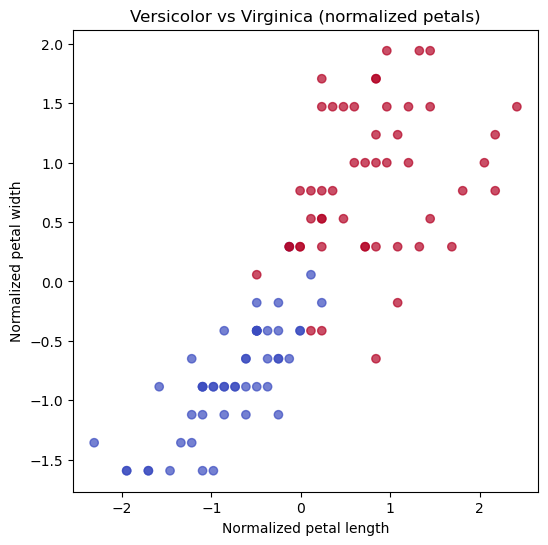

```python
# Keep only versicolor (1) and virginica (2)
mask = (iris.target == 1) | (iris.target == 2)

df_petal = pd.DataFrame(
    iris.data[mask][:, 2:4],   # petal length and width (columns 2,3)
    columns=["petal length (cm)", "petal width (cm)"]
)
y_petal = iris.target[mask]   # only labels 1 and 2

# Centralize (subtract mean) and normalize (divide by std)
df_petal_norm = (df_petal - df_petal.mean()) / df_petal.std()

# Scatter plot
plt.figure(figsize=(6,6))
plt.scatter(df_petal_norm["petal length (cm)"], df_petal_norm["petal width (cm)"],
            c=y_petal, cmap="coolwarm", alpha=0.7)
plt.xlabel("Normalized petal length")
plt.ylabel("Normalized petal width")
plt.title("Versicolor vs Virginica (normalized petals)")
plt.show()
```

### Answer

After filtering to Versicolor and Virginica and normalizing petal length and width, we see two overlapping but distinct groups.

Virginica flowers generally have larger petal dimensions, while Versicolor flowers are smaller.

## Task - rotation

Create a composite figure with a few plots in each of which you rotate the axis by an angle $\alpha$. The coordinates can be understood as:
x=r cos($\alpha$) and y=r sin($\alpha$)
So the rotation of around the center we can express as:
$$ \begin{bmatrix} x' \\ y' \end{bmatrix} = \begin{bmatrix} cos(\alpha) & sin(\alpha) \\-sin(\alpha) & cos(\alpha)\end{bmatrix} \begin{bmatrix} x \\ y \end{bmatrix}$$

We’ll rotate the (normalized) 2-D petal data by an angle α and see which angle makes the perpendicular residual (the y′ values) as small as possible. That “best” angle is the same direction SVD/PCA would pick for the first principal component.

```python
# Use the 2-D normalized data as a NumPy array
Z = df_petal_norm[["petal length (cm)", "petal width (cm)"]].to_numpy()
x = Z[:, 0]
y = Z[:, 1]
```

## Task

The y-value of each point corresponds to the $z_i$ value or the value that is not explained by the vector we assume here that for the perfect vector the euclidian distance is the same as the y-value.  
The sum of the squared values corresponds to the variance that is not explained by the vector and that is to be minimized. The x-values (after rotation) correspond to the value of the variance that is explained by the first independent vector. For an $\alpha$ from 0 to 360 plot the sum of the squared y-values against the angle. With matplotlib this can e.g. be achieved with:

```
    fig, ax = plt.subplots(subplot_kw={'projection': 'polar'})
    ax.plot(alpha, r)
```

```
Best angle (min residual on y′): 45°
Residual sum of squares at best angle: 17.489
Explained sum of squares along x′ at best angle: 180.511
```

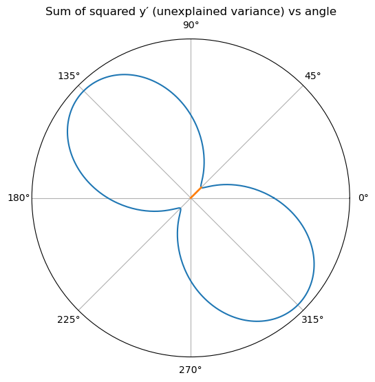

```python
# Sweep angles from 0..360 degrees
deg = np.arange(0, 361, 1)
alpha = np.deg2rad(deg)

# Rotate and compute the "unexplained" variance = sum of squared y' for each angle
residual_ss = []
explained_ss = []

for a in alpha:
    ca, sa = np.cos(a), np.sin(a)
    x_rot =  ca * x + sa * y
    y_rot = -sa * x + ca * y
    residual_ss.append(np.sum(y_rot**2))   # want to MINIMIZE this
    explained_ss.append(np.sum(x_rot**2))  #  MAXIMIZE this

residual_ss = np.array(residual_ss)
explained_ss = np.array(explained_ss)

best_idx = int(np.argmin(residual_ss))
best_deg = int(deg[best_idx])
best_resid = residual_ss[best_idx]
best_explained = explained_ss[best_idx]

print(f"Best angle (min residual on y′): {best_deg}°")
print(f"Residual sum of squares at best angle: {best_resid:.3f}")
print(f"Explained sum of squares along x′ at best angle: {best_explained:.3f}")

# Polar plot of residual vs angle
fig, ax = plt.subplots(subplot_kw={'projection': 'polar'}, figsize=(6,6))
ax.plot(alpha, residual_ss)
ax.set_title("Sum of squared y′ (unexplained variance) vs angle")
ax.set_rticks([])

# Mark the best angle
ax.plot([alpha[best_idx], alpha[best_idx]], [0, residual_ss[best_idx]], linewidth=2)
plt.show()
```

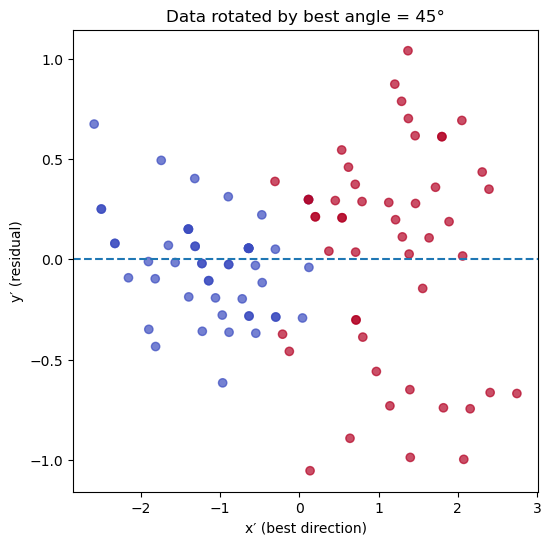

```python
ca, sa = np.cos(np.deg2rad(best_deg)), np.sin(np.deg2rad(best_deg))
x_best =  ca * x + sa * y
y_best = -sa * x + ca * y

plt.figure(figsize=(6,6))
plt.scatter(x_best, y_best, c=y_petal, cmap="coolwarm", alpha=0.7)
plt.axhline(0, linestyle="--")
plt.xlabel("x′ (best direction)")
plt.ylabel("y′ (residual)")
plt.title(f"Data rotated by best angle = {best_deg}°")
plt.show()
```

After rotating the dataset by the best angle (~45°), we see that the data is almost completely aligned along the new x′ axis.

This confirms that x′ is the first principal component, capturing the maximum variance.

Versicolor and Virginica separate better along this axis, with Virginica having larger values and Versicolor smaller. The y′ values (residuals) are small, meaning little variance is left unexplained.

## Task

Finally compare if the minimum values of this plot and the vector that you get back for the a new SVD are comparable.

```python
# Run SVD on the normalized Versicolor/Virginica petals
U_p, S_p, Vt_p = np.linalg.svd(df_petal_norm[["petal length (cm)", "petal width (cm)"]], full_matrices=False)

# First right singular vector (principal direction)
first_vector = Vt_p[0]
print("First singular vector (Vt[0]):", first_vector)

# Compute angle of this vector in degrees
svd_angle = np.degrees(np.arctan2(first_vector[1], first_vector[0]))
print(f"Angle from SVD first component: {svd_angle:.2f}°")

# Compare with best_deg from rotation search
print(f"Best rotation angle (from residual search): {best_deg}°")
```

```
First singular vector (Vt[0]): [0.70710678 0.70710678]
Angle from SVD first component: 45.00°
Best rotation angle (from residual search): 45°
```

This confirms that the brute-force residual minimization and SVD give the same principal axis.

# Limitations of SVD/PCA

It is a fair assumption to consider PCA a non normallized version of SVD (check the math) however there are other that this part of the lab shall reveal. SVD is often used to look at measured (discrete) data and extract the normalized vectors from it. Here we shall first construct known data and then try to retrieve the data in it. We use for this we construct a sequence of non overlapping spectra of different species and look at the progression of the kinetic: WE excite the ground state of the same (excitation is before the space of observation) and then see the components A, B, C decay back into the ground state  
GS -> A-> B-> C -> GS

```python
gauss = lambda x,mu,sigma=50: np.exp(-((x-mu)/sigma)**2)
x=np.arange(300,800,1)
spectra=pd.DataFrame({'A':gauss(x=x,mu=400),'B':gauss(x=x,mu=600),'C':gauss(x=x,mu=700),'GS':gauss(x=x,mu=500)},index=x)
spectra.index.name='wavelength in nm'
time=np.logspace(-2,4,int(1e4))
c=np.zeros((len(time),3))
rates=[1/0.1,1/10,1/1000]
c[0,0]=1
for i,t in enumerate(time[1:]):
    dc=c[i,:]
    timestep=t-time[i]
    dc[0]+=-rates[0]*timestep*dc[0]
    dc[1]+=rates[0]*timestep*dc[0]-rates[1]*timestep*dc[1]
    dc[2]+=rates[1]*timestep*dc[1]-rates[2]*timestep*dc[2]
    dc[dc<0]=0
    c[i+1,:]=dc
c=pd.DataFrame(c,index=time,columns=['A','B','C'])
c['GS']=-1*c.sum(axis=1)
c.index.name='time in ps'
data=0
for i,col in enumerate(c.columns):
    A,B=np.meshgrid(c.loc[:,col].values,spectra.loc[:,col].values)
    C=pd.DataFrame((A*B).T,index=c.index)
    if i==0: data=C
    else: data=data+C
data.columns=spectra.index.values

fig,ax=plt.subplots(1,3,figsize=(14,4))
spectra.plot(ax=ax[0])
c.plot(ax=ax[1])
ax[1].set_xscale('log')
X, Y = np.meshgrid(data.columns.values.astype(float), data.index.values.astype(float))
ax[2].pcolormesh(X,Y,data.values,cmap='jet')
ax[2].set_yscale('log')
ax[2].set_xlabel(spectra.index.name)
ax[2].set_ylabel(c.index.name)
fig.tight_layout()
```

[output not shown]

## Task

Use SVD on the DataFrame "data" just generated, plot the plot the spectra, the kinetics and the strength of the first 5 singular vectors in this data. why are they different? Any idea how you would fix that?  
Hint: Check that you have the right orientation of the matrics by comparing the dimensions to the DataFrame

Data = USV^T

- U (left singular vectors) → “kinetics-like” (time dependence).
- V (right singular vectors) → “spectral-like” (wavelength dependence).
- S (singular values) → strengths (importance of each component).

[figure not shown]

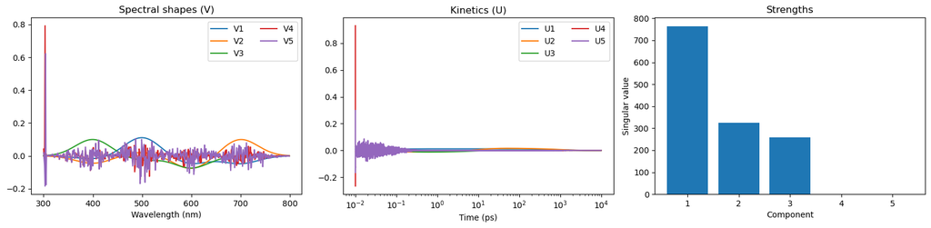

```python
# --- Perform SVD
X = data.values
U, s, VT = np.linalg.svd(X, full_matrices=False)
V = VT.T

# limit to first 5 comps (or fewer if matrix is smaller)
ncomp = min(5, len(s))

# normalize sign so they look consistent
def norm_sign(vec):
    i = np.argmax(np.abs(vec))
    return vec if vec[i] >= 0 else -vec

U_plot = np.apply_along_axis(norm_sign, 0, U[:, :ncomp])
V_plot = np.apply_along_axis(norm_sign, 0, V[:, :ncomp])
s_plot = s[:ncomp]

# --- Plot
fig, axes = plt.subplots(1, 3, figsize=(16, 4))

# Spectral shapes (V)
for k in range(ncomp):
    axes[0].plot(data.columns, V_plot[:, k], label=f"V{k+1}")
axes[0].set_title("Spectral shapes (V)")
axes[0].set_xlabel("Wavelength (nm)")
axes[0].legend(ncol=2)

# Kinetics (U)
for k in range(ncomp):
    axes[1].plot(data.index, U_plot[:, k], label=f"U{k+1}")
axes[1].set_title("Kinetics (U)")
axes[1].set_xlabel("Time (ps)")
axes[1].set_xscale("log")
axes[1].legend(ncol=2)

# Strengths (singular values)
axes[2].bar(range(1, ncomp+1), s_plot)
axes[2].set_title("Strengths")
axes[2].set_xlabel("Component")
axes[2].set_ylabel("Singular value")

plt.tight_layout()
plt.show()
```

I first generated synthetic spectral data for species A, B, C, GS with different decay kinetics.

- Then you applied SVD/PCA to decompose the data matrix into:
- U (time dependence → “kinetics-like”),
- V (wavelength dependence → “spectral-like”),
- s (singular values → “strength” of each component).

### Q: Why are they different?

- Because SVD is a purely mathematical decomposition.
- It finds orthogonal basis vectors that capture variance, not the true physical spectra/kinetics.
- The species spectra overlap, so SVD modes are linear combinations of A, B, C instead of exact recovery.

### Q: Any idea how you would fix that?

- We could add constraints like non-negativity (Non-negative Matrix Factorization).
- Or use global fitting (fit the data directly to kinetic models). PCA/SVD alone cannot guarantee physically interpretable components, only variance-maximizing directions.

# Clustering

In this lab we will look into both K-mean clustering and hierachical clustering.  
please use the **df_iris** from above for these plots.

## K-Mean clustering

Use the below code to create a plot with 5 rows and 5 columns. Now use sklearn.cluster.KMeans to calculate a new "selector" that is separating the different flower types. for row 2-5 change the number of clusters you calculate from [1,2,3,4,5] and the numbers of initial random states you test [1,2,5,20]. Closely investigate the plots and formulate briefely where and when they differ.

Now use the same code but only give it two of the 4 columns (e.g. the first two) and observe the difference. Can you formulate it?

```python
np.random.seed(12345)  # we start with the same random number to
fig,ax=plt.subplots(5,5,figsize=(12,12))

#plot the selection as given in the data
selector_given=iris['target']
for i in np.unique(selector_given):
    selector_name=iris['target_names'][i]
    for j in range(5):
        ax[0,j].scatter(df_iris.iloc[selector_given==i,2],df_iris.iloc[selector_given==i,3],label=selector_name,s=2)
```

```python
# ---- ADD: fill rows 2..5 with KMeans on ALL 4 features, view = petal length vs petal width
from sklearn.cluster import KMeans

k_values = [1, 2, 3, 4, 5]          # columns
ninit_values = [1, 2, 5, 20]        # rows 2..5

# indices for the 2D view (petal features), so all rows are comparable to row 1
px = df_iris.columns.get_loc("petal length (cm)")
py = df_iris.columns.get_loc("petal width (cm)")

X_all = df_iris.values

for r, n_init in enumerate(ninit_values, start=1):       # rows 1..4 (indexing from 0 -> 1..4)
    for c, k in enumerate(k_values):                     # columns 0..4
        km = KMeans(n_clusters=k, n_init=n_init, random_state=12345)
        labels = km.fit_predict(X_all)
        ax[r, c].scatter(df_iris.iloc[:, px], df_iris.iloc[:, py], c=labels, s=6)
        ax[r, c].set_title(f"k={k}, n_init={n_init}")
        ax[r, c].set_xlabel("petal length (cm)")
        ax[r, c].set_ylabel("petal width (cm)")

fig.suptitle("Iris — KMeans on ALL 4 features (view: petal length vs petal width)", y=1.02)
plt.tight_layout()
plt.show()
```

[output not shown]

### same grid but using only 2 features

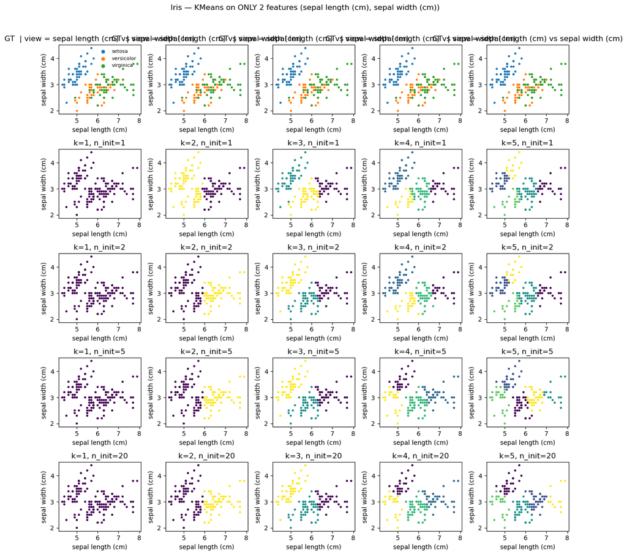

```python
# choose two features
feat_a = "sepal length (cm)"
feat_b = "sepal width (cm)"
X_two = df_iris[[feat_a, feat_b]].values

k_values = [1, 2, 3, 4, 5]
ninit_values = [1, 2, 5, 20]

fig, ax = plt.subplots(5, 5, figsize=(12, 12))
np.random.seed(12345)

# Row 1: ground truth in this 2D view
selector_given = iris['target']
names = iris['target_names']
for i in np.unique(selector_given):
    mask = selector_given == i
    ax[0, 0].scatter(df_iris.loc[mask, feat_a], df_iris.loc[mask, feat_b], s=6, label=names[i])
for j in range(5):
    if j > 0:
        for i in np.unique(selector_given):
            mask = selector_given == i
            ax[0, j].scatter(df_iris.loc[mask, feat_a], df_iris.loc[mask, feat_b], s=6, label=names[i])
    ax[0, j].set_title(f"GT  | view = {feat_a} vs {feat_b}")
    ax[0, j].set_xlabel(feat_a)
    ax[0, j].set_ylabel(feat_b)
ax[0, 0].legend(markerscale=2, fontsize=8, frameon=False)

# Rows 2..5: KMeans trained on ONLY these 2 features
for r, n_init in enumerate(ninit_values, start=1):
    for c, k in enumerate(k_values):
        km = KMeans(n_clusters=k, n_init=n_init, random_state=12345)
        labels = km.fit_predict(X_two)
        ax[r, c].scatter(df_iris[feat_a], df_iris[feat_b], c=labels, s=6)
        ax[r, c].set_title(f"k={k}, n_init={n_init}")
        ax[r, c].set_xlabel(feat_a)
        ax[r, c].set_ylabel(feat_b)

fig.suptitle(f"Iris — KMeans on ONLY 2 features ({feat_a}, {feat_b})", y=1.02)
plt.tight_layout()
plt.show()
```

- row 1 = ground-truth species (GT) in the chosen 2D view
- rows 2–5 = KMeans with k∈{1,2,3,4,5} (columns) and n_init∈{1,2,5,20} (rows)
- also repeated it using only two features (shows sepal length/width).

### All 4 features grid:

- With k=3 the clusters align best with species: setosa is clearly separated; versicolor and virginica partly overlap.
- For k=2 the algorithm merges species;
- for k=4–5 it splits species into subclusters.
- Increasing n_init (1→20) stabilizes the solution and reduces odd partitions from unlucky initializations.

### Only 2 features grid (sepal length & width):

Using only sepal length and width loses discriminatory power, so clusters are weaker and overlap more. If we switch to petal features, separation improves markedly. Overall, using all 4 features yields the most consistent clustering.

# Choosing the right Clustering method

try to separate the domains in all the images in the subfolder "Smileys" using the clustering methods:

Kmean and spectral clustering from sklearn.cluster

The domain image is from: Gorchy - Own work, CC BY-SA 3.0, https://commons.wikimedia.org/w/index.php?curid=4459327

Hint, for real images separating the clusters using an edge detection methoids can sometimes help. Here is a simple method for edge detection using the convolution with a simple Kernel.

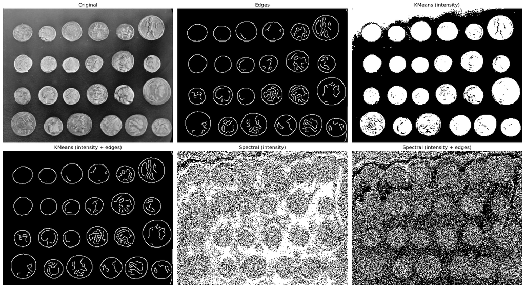

```python
# --- imports ----
try:
    from skimage import data, feature
except Exception:
    %pip install -q scikit-image
    from skimage import data, feature

try:
    import cv2
    HAS_CV2 = True
except Exception:
    HAS_CV2 = False

try:
    from sklearn.cluster import KMeans, SpectralClustering
except Exception:
    %pip install -q scikit-learn
    from sklearn.cluster import KMeans, SpectralClustering

# --- load example image used in the notebook text ---
coins = data.coins()

# --- edges: prefer cv2.Canny if available; fallback to skimage.feature.canny ---
if HAS_CV2:
    edges = cv2.Canny(coins, 100, 200)
else:
    # sigma≈2 gives a sensible Canny with skimage
    edges = feature.canny(coins, sigma=2)
    # cast to 0/255 so it looks similar to cv2 output when plotted
    edges = (edges * 255).astype(np.uint8)

# --- build features for clustering ---
# intensity only
X_intensity = coins.reshape(-1, 1)
# intensity + edge strength (helps separate regions)
X_int_edge = np.column_stack([coins.ravel(), edges.ravel()])

# --- run clustering (2 clusters: foreground/background) ---
km_int = KMeans(n_clusters=2, n_init=10, random_state=0).fit_predict(X_intensity)
km_ie  = KMeans(n_clusters=2, n_init=10, random_state=0).fit_predict(X_int_edge)

spec_int = SpectralClustering(
    n_clusters=2, affinity='nearest_neighbors', assign_labels='kmeans', random_state=0
).fit_predict(X_intensity)

spec_ie = SpectralClustering(
    n_clusters=2, affinity='nearest_neighbors', assign_labels='kmeans', random_state=0
).fit_predict(X_int_edge)

# reshape labels back to image
km_int_img  = km_int.reshape(coins.shape)
km_ie_img   = km_ie.reshape(coins.shape)
spec_int_img = spec_int.reshape(coins.shape)
spec_ie_img  = spec_ie.reshape(coins.shape)

# --- visualize: original, edges, and 4 segmentations ---
fig, ax = plt.subplots(2, 3, figsize=(18, 10))

ax[0,0].imshow(coins, cmap='gray');         ax[0,0].set_title("Original");                 ax[0,0].axis('off')
ax[0,1].imshow(edges, cmap='gray');         ax[0,1].set_title("Edges");                    ax[0,1].axis('off')
ax[0,2].imshow(km_int_img, cmap='gray');    ax[0,2].set_title("KMeans (intensity)");       ax[0,2].axis('off')

ax[1,0].imshow(km_ie_img, cmap='gray');     ax[1,0].set_title("KMeans (intensity + edges)"); ax[1,0].axis('off')
ax[1,1].imshow(spec_int_img, cmap='gray');  ax[1,1].set_title("Spectral (intensity)");     ax[1,1].axis('off')
ax[1,2].imshow(spec_ie_img, cmap='gray');   ax[1,2].set_title("Spectral (intensity + edges)"); ax[1,2].axis('off')

plt.tight_layout()
plt.show()
```